# Homework 4

Román Vélez Jiménez

# Homework Permutation tests

# 4.1: Tips

```r
library(tidyverse)
library(nullabor)
```

## 4.1.1: Tips data

Q: Does the tips are different between meal and dinner?

```r
df_tips <- read_csv("../../data/propinas.csv")
df_tips |> head()
```

| cuenta_total | propina | fumador | dia | momento | num_personas |
| --- | --- | --- | --- | --- | --- |
| 16.99 | 1.01 | No | Dom | Cena | 2 |
| 10.34 | 1.66 | No | Dom | Cena | 3 |
| 21.01 | 3.50 | No | Dom | Cena | 3 |
| 23.68 | 3.31 | No | Dom | Cena | 2 |
| 24.59 | 3.61 | No | Dom | Cena | 4 |
| 25.29 | 4.71 | No | Dom | Cena | 4 |

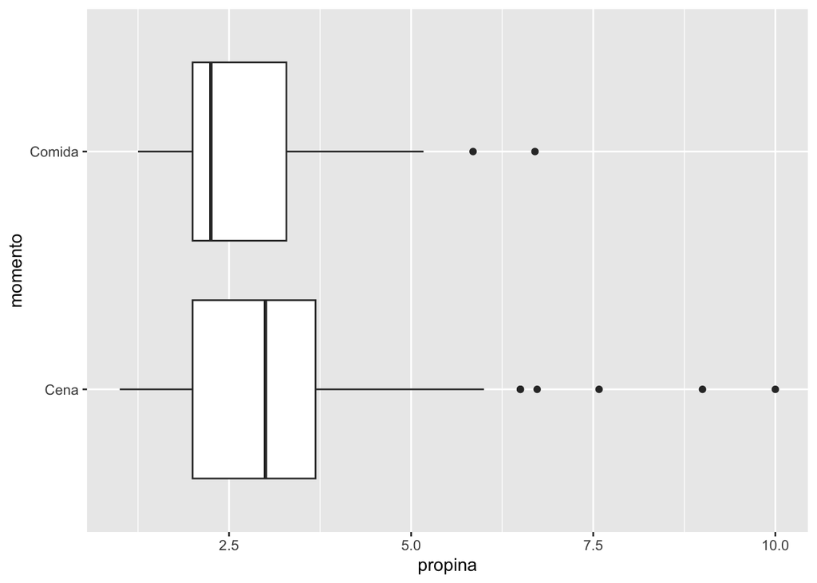

```r
df_tips |>
  ggplot(aes(momento, propina)) +
  geom_boxplot() +
  coord_flip()
```

```r
set.seed(8)
df_perm <- lineup(
  method = null_permute("momento"),
  true = df_tips,
  n = 12
)
```

```
## decrypt("sD0f gCdC En JP2EdEPn Zj")
```

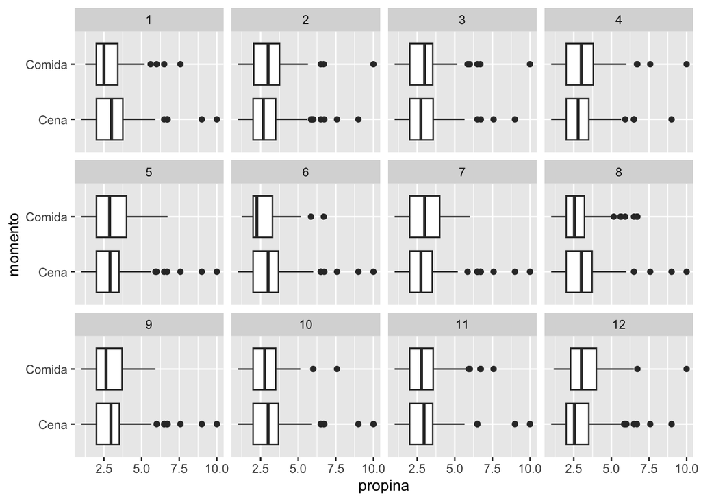

```r
df_perm |>
  ggplot(aes(momento, propina)) +
  geom_boxplot() +
  coord_flip() +
  facet_wrap(~ .sample)
```

My shoot is num 1.

```r
decrypt("sD0f gCdC En JP2EdEPn Zj")
```

```
## [1] "True data in position  6"
```

Noup, I couldn’t guess it. I think this visual test does not give evidence that both distributions aren’t the same, but I think it also does not gives too much evidence that distributions are the same.

# ——

## 4.1.2: Linear Relationship Bill vs Tip

Does there exist some linear relationship between bill & tip?

```r
# permute
set.seed(8)
df_perm <- lineup(
  method = null_permute("propina"),
  true = df_tips,
  n = 12
)
```

```
## decrypt("sD0f gCdC En JP2EdEPn Zj")
```

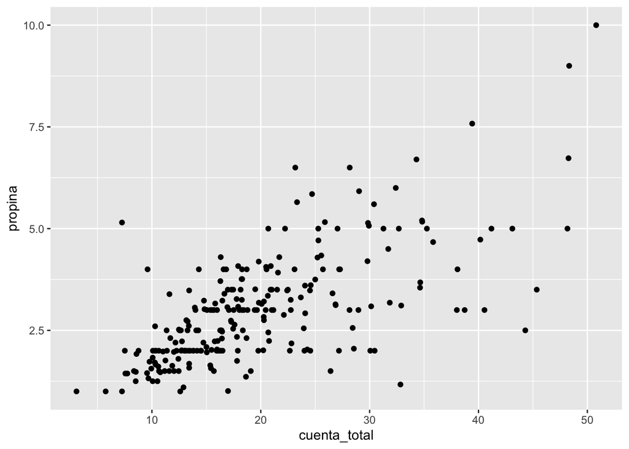

```r
# plot original
df_tips |>
  ggplot(aes(cuenta_total, propina)) +
  geom_point()
```

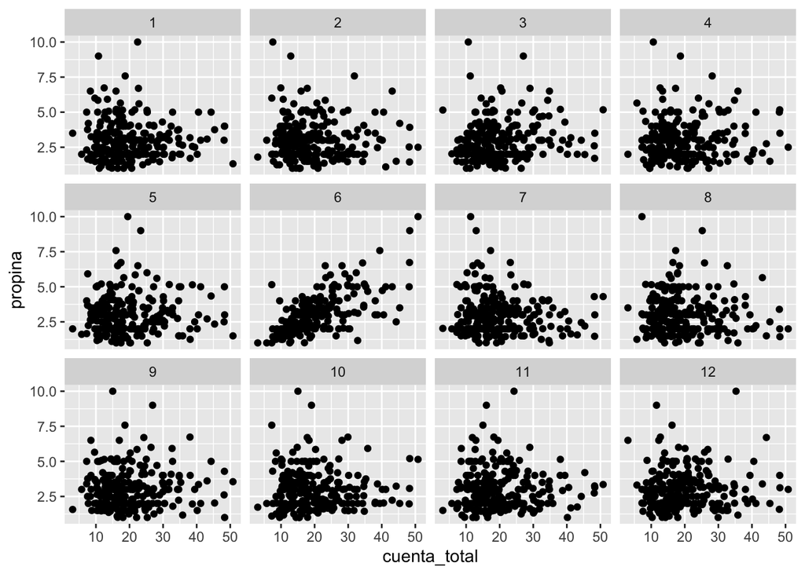

```r
# plot samples
df_perm |>
  ggplot(aes(cuenta_total, propina)) +
  geom_point() +
  facet_wrap(~ .sample)
```

My shoot is num 6

```r
decrypt("sD0f gCdC En JP2EdEPn Zj")
```

```
## [1] "True data in position  6"
```

Nailed it. This gives sufficient evidence that there is a linear relationship between bills & tips. I have 0.0833333 of significance.

# 4.1.3: Mean Difference Tips

```r
# perumute
set.seed(8)
df_perm <- lineup(
  method = null_permute("momento"),
  true = df_tips,
  n = 5000
)
```

```
## decrypt("sD0f gCdC En JP2EdEPn T8OO")
```

```r
# summary
df_summ_mean <- df_perm |>
  group_by(momento, .sample) |>
  summarise(mean_tip = mean(propina)) |>
  pivot_wider(names_from = momento, values_from = mean_tip) |>
  mutate(diff_mean = Cena - Comida)
# print
df_summ_mean |> head()
```

| .sample | Cena | Comida | diff_mean |
| --- | --- | --- | --- |
| 1 | 3.058125 | 2.843382 | 0.21474265 |
| 2 | 2.932045 | 3.169706 | -0.23766043 |
| 3 | 2.929148 | 3.177206 | -0.24805816 |
| 4 | 2.903977 | 3.242353 | -0.33837567 |
| 5 | 2.944659 | 3.137059 | -0.19239973 |
| 6 | 2.974545 | 3.059706 | -0.08516043 |

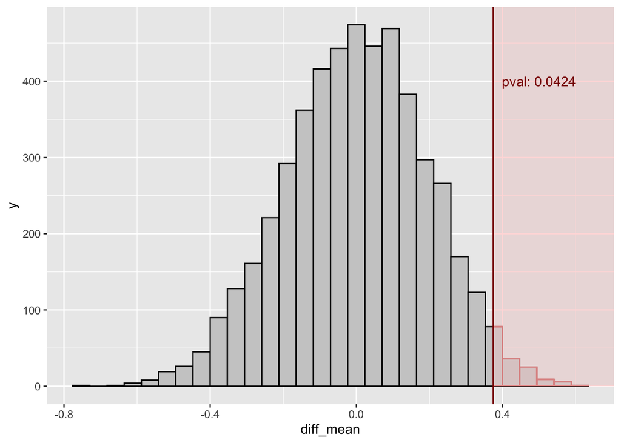

```r
# true mean
mean_tips <- df_tips |>
  group_by(momento) |>
  summarise(mean_tip = mean(propina)) |>
  pivot_wider(names_from = momento, values_from = mean_tip) |>
  mutate(diff_mean = Cena - Comida) |>
  pull(diff_mean)

# pvalue
dist_ref <- ecdf(df_summ_mean$diff_mean)
stat_diff <- dist_ref(mean_tips)
pval <- 2 * min(stat_diff, (1 - stat_diff))

# histogram
df_summ_mean |>
  ggplot(aes(diff_mean)) +
  geom_histogram(color = "black", fill = "gray80") +
  geom_rect(aes(xmin = mean_tips, xmax = Inf, ymin = 0, ymax = Inf), fill = "pink", alpha = 0.01) +
  geom_vline(xintercept = mean_tips, color = "darkred") +
  annotate("text", x = 0.5, y = 400, label = str_glue("pval: {pval}"), color = "darkred")
```

I think there is evidence to think that there is a difference between meal and dinner tips, without controlling other variables such as size of the bill, the number of people and the day of the week. But also, if there are simulations without the control variables, this effects should cancel out in the simulation

# 4.2: Phillies data

## 4.2.1: Phillies

Read data

```r
df_phil <- read_csv("../../data/Phillies2009.csv")
df_phil |> head()
```

| Date | Location | Outcome | Hits | Doubles | HomeRuns | StrikeOuts |
| --- | --- | --- | --- | --- | --- | --- |
| 5-Apr | Home | Lose | 4 | 2 | 0 | 6 |
| 7-Apr | Home | Lose | 6 | 1 | 0 | 3 |
| 8-Apr | Home | Win | 11 | 3 | 1 | 6 |
| 10-Apr | Away | Lose | 7 | 2 | 1 | 3 |
| 11-Apr | Away | Win | 15 | 3 | 1 | 6 |
| 12-Apr | Away | Win | 13 | 3 | 2 | 4 |

### 4.2.1.a: lineups

```r
# create permutations
set.seed(8)
df_perm <- lineup(
  method = null_permute("Location"),
  true = df_phil,
  n = 12
)
```

```
## decrypt("sD0f gCdC En JP2EdEPn 8Z")
```

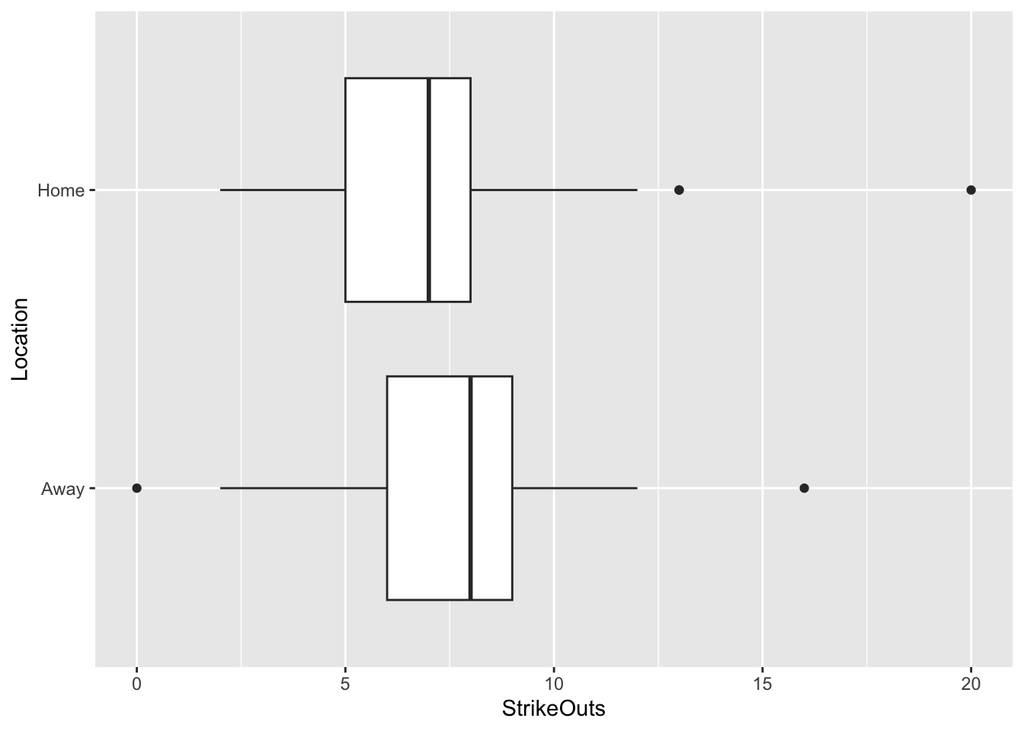

```r
# real data:
df_phil |>
  ggplot(aes(Location, StrikeOuts)) +
  geom_boxplot() +
  coord_flip()
```

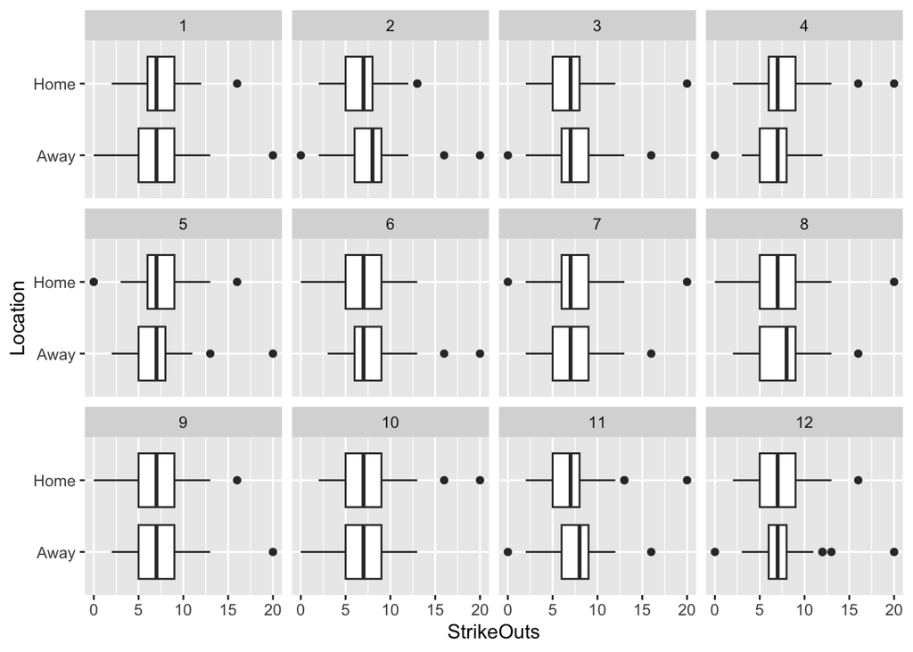

```r
# perms
df_perm |>
  ggplot(aes(Location, StrikeOuts)) +
  geom_boxplot() +
  coord_flip() +
  facet_wrap(~ .sample)
```

My guess is *num 11*.

```r
decrypt("sD0f gCdC En JP2EdEPn 8Z")
```

```
## [1] "True data in position  11"
```

Got it. I have, somewhat, evidence that the distribution between them isn’t the same.

```r
# mean per game
df_phil |>
  group_by(Location) |>
  summarize(mean_strikes_out = mean(StrikeOuts))
```

| Location | mean_strikes_out |
| --- | --- |
| Away | 7.308642 |
| Home | 6.950617 |

```r
# get mean
mean_strikes <- df_phil |>
  group_by(Location) |>
  summarize(mean_strikes_out = mean(StrikeOuts)) |>
  pivot_wider(names_from = Location, values_from = mean_strikes_out) |>
  mutate(diff = Home - Away) |>
  pull(diff)
```

```r
set.seed(8)
df_perm <- lineup(
  method = null_permute("Location"),
  true = df_phil,
  n = 5000
)
```

```
## decrypt("sD0f gCdC En JP2EdEPn OTB8")
```

```r
# summary
df_summ_mean <- df_perm |>
  group_by(Location, .sample) |>
  summarize(mean_strikes_out = mean(StrikeOuts)) |>
  pivot_wider(names_from = Location, values_from = mean_strikes_out) |>
  mutate(diff = Home - Away)
```

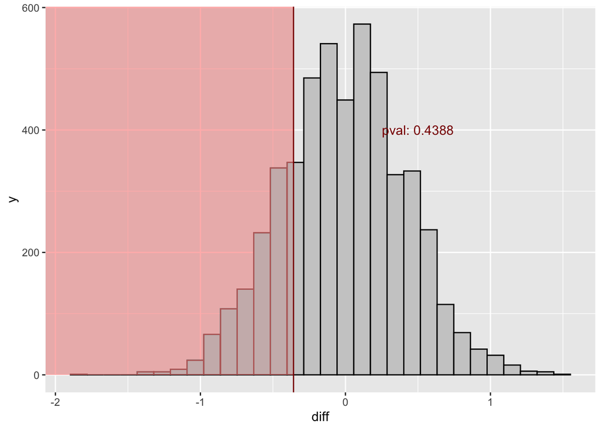

```r
# pvalue
dist_ref <- ecdf(df_summ_mean$diff)
stat_diff <- dist_ref(mean_strikes)
pval <- 2 * min(stat_diff, (1 - stat_diff))

# histogram
df_summ_mean |>
  ggplot(aes(diff)) +
  geom_histogram(color = "black", fill = "gray80") +
  geom_rect(aes(xmax = mean_strikes, xmin = -Inf, ymin = 0, ymax = Inf), fill = "pink", alpha = 0.01) +
  geom_vline(xintercept = mean_strikes, color = "darkred") +
  annotate("text", x = 0.5, y = 400, label = str_glue("pval: {pval}"), color = "darkred")
```

# 4.2.2: paired tests

- En este ejemplo buscamos comparar la diferencia entre dos medicinas para dormir.
- ID es el identificador de paciente, group el identificador de la medicina, y extra son las horas extras de sueño.

```r
df_sleep <- sleep |> as_tibble()
df_sleep
```

| extra | group | ID |
| --- | --- | --- |
| 0.7 | 1 | 1 |
| -1.6 | 1 | 2 |
| -0.2 | 1 | 3 |
| -1.2 | 1 | 4 |
| -0.1 | 1 | 5 |
| 3.4 | 1 | 6 |
| 3.7 | 1 | 7 |
| 0.8 | 1 | 8 |
| 0.0 | 1 | 9 |
| 2.0 | 1 | 10 |

[output cut: 10 more lines]

La pregunta de interés es si una medicina es mejor que otra para prolongar el sueño. Nótese que en este caso, no tenemos grupos, sino mediciones repetidas.

1. Null hypothesis $\mathcal{H}_{0}$: there do not exist difference of sleep between medicines.
2. Stat of interest: $D = \bar{X} - \bar{Y}$. Where $X$ is medicine 1 and $Y$ is medicine 2.

```r
mean_diff <-  df_sleep |>
  group_by(group) |>
  summarize(mean_sleep = mean(extra)) |>
  mutate(group = str_glue("group_{group}")) |>
  pivot_wider(names_from = group, values_from = mean_sleep) |>
  mutate(diff = group_1 - group_2) |>
  pull(diff)
```

3. Are the amount of time of sleep the same between them?

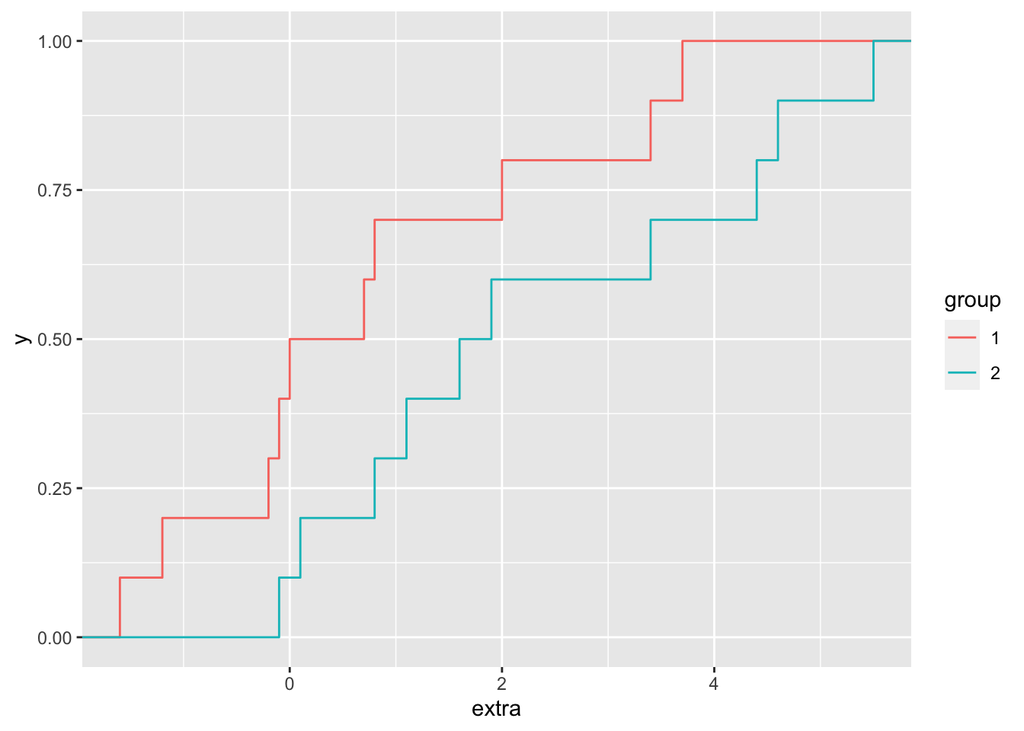

```r
# difference in time between groups
df_sleep |>
  ggplot(aes(extra, color = group)) +
  stat_ecdf()
```

```r
set.seed(8)
df_perm <- lineup(
  method = null_permute("extra"),
  true = df_sleep,
  n = 5000
)
```

```
## decrypt("sD0f gCdC En JP2EdEPn OB8T")
```

```r
# summary
df_summ_mean <- df_perm |>
  group_by(group, .sample) |>
  summarize(mean_sleep = mean(extra)) |>
  mutate(group = str_glue("group_{group}")) |>
  pivot_wider(names_from = group, values_from = mean_sleep) |>
  mutate(diff = group_1 - group_2)
```

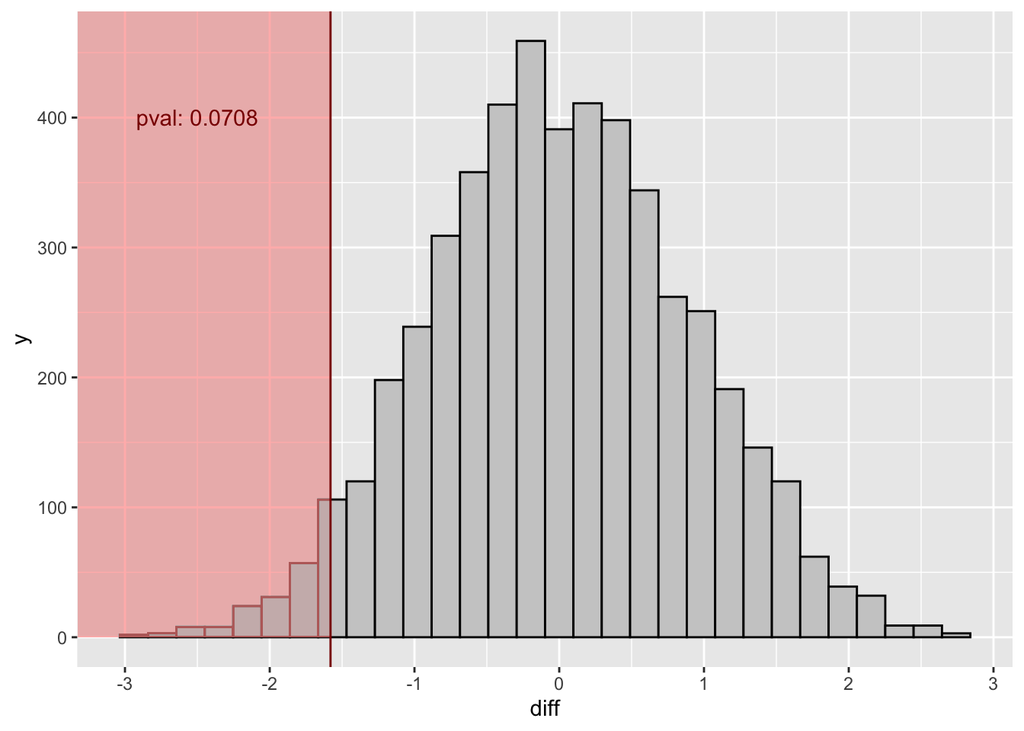

```r
# pvalue
dist_ref <- ecdf(df_summ_mean$diff)
stat_diff <- dist_ref(mean_diff)
pval <- 2 * min(stat_diff, (1 - stat_diff))

# histogram
df_summ_mean |>
  ggplot(aes(diff)) +
  geom_histogram(color = "black", fill = "gray80") +
  geom_rect(aes(xmax = mean_diff, xmin = -Inf, ymin = 0, ymax = Inf), fill = "pink", alpha = 0.01) +
  geom_vline(xintercept = mean_diff, color = "darkred") +
  annotate("text", x = -2.5, y = 400, label = str_glue("pval: {pval}"), color = "darkred")
```

### 4.2.4 P-value

For the stat $\hat{P} = (X+1)/(N+1)$ what is the respective variance?

Getting the variance should be (WIP)
$$\text{Var}(P) = Var((X+1)/(N+1)) = Var(X/(N+1)) = N/(N+1)^2\sigma^2$$